# Original Study: Data Analysis

Group 10

```r
#loading for analysis prepared data table
animal <- read.csv("animal_data.csv")
```

## Data Analysis - Original Study

For the main trials of our experiment we hold the following research hypotheses:

H1: The area under the curve (AUC) is larger for atypical trials compared to typical trials.

H2: The maximal absolute deviation (MAD) is larger for atypical trials compared to typical trials.

H3: Movement duration is longer for atypical trials compared to typical trials.

H4: The likelihood of obtaining different cluster types depends on the experimental conditions.

H5: The total categorisation response time is longer for atypical trials compared to typical trials.

H6: The movement initiation latency is longer for atypical trials compared to typical trials.

H7: The distance travelled in pixels is longer for atypical trials compared to typical trials.

# REGRESSION MODELS

Hypothesis 1

```r
#Taking absolute AUC values, since negative AUC make no sense
animal$AUC_abs = abs(animal$AUC)
animal$AUC_abs_s = my_scale(animal$AUC_abs)

#informative prior
prior_hypo1 <- c(
  #priors for all fixed effects (trial_type)
  set_prior("student_t(3, 0,2)", class = "sigma"),
  #prior for the Intercept
  set_prior("student_t(3, -0.5,2)", class = "Intercept"),
  #prior for all SDs including the varying intercepts and slopes
  set_prior("student_t(3, 0, 2)", class = "sd")
)

#by-subject_id varying intercepts and varying
#slope, without slope/intercept correlation
#by-exemplar varying intercept
model_hypo1 = brm(
  AUC_abs_s ~ trial_type +
    (trial_type || subject_id)+
    (1 |exemplar),
  control=list(adapt_delta=0.99, max_treedepth=15),
  data = animal,
  prior = prior_hypo1
  )

#looking at model output
model_hypo1
```

```
##  Family: gaussian
##   Links: mu = identity; sigma = identity
## Formula: AUC_abs_s ~ trial_type + (trial_type || subject_id) + (1 | exemplar)
##    Data: animal (Number of observations: 598)
## Samples: 4 chains, each with iter = 2000; warmup = 1000; thin = 1;
##          total post-warmup samples = 4000
##
## Group-Level Effects:
## ~exemplar (Number of levels: 15)
##               Estimate Est.Error l-95% CI u-95% CI Rhat Bulk_ESS Tail_ESS
## sd(Intercept)     0.09      0.06     0.01     0.23 1.00     1164     1316
##
## ~subject_id (Number of levels: 53)
##                       Estimate Est.Error l-95% CI u-95% CI Rhat Bulk_ESS
## sd(Intercept)             0.59      0.10     0.43     0.80 1.01      465
## sd(trial_typeTypical)     0.31      0.15     0.03     0.60 1.02      225
##                       Tail_ESS
## sd(Intercept)             1725
## sd(trial_typeTypical)      487
##
## Population-Level Effects:
##                   Estimate Est.Error l-95% CI u-95% CI Rhat Bulk_ESS Tail_ESS
## Intercept             0.31      0.12     0.08     0.54 1.00     2231     3212
## trial_typeTypical    -0.35      0.11    -0.57    -0.14 1.00     3872     2903
##
## Family Specific Parameters:
##       Estimate Est.Error l-95% CI u-95% CI Rhat Bulk_ESS Tail_ESS
## sigma     0.84      0.03     0.78     0.90 1.00      846     2158
##
## Samples were drawn using sampling(NUTS). For each parameter, Bulk_ESS
## and Tail_ESS are effective sample size measures, and Rhat is the potential
## scale reduction factor on split chains (at convergence, Rhat = 1).
```

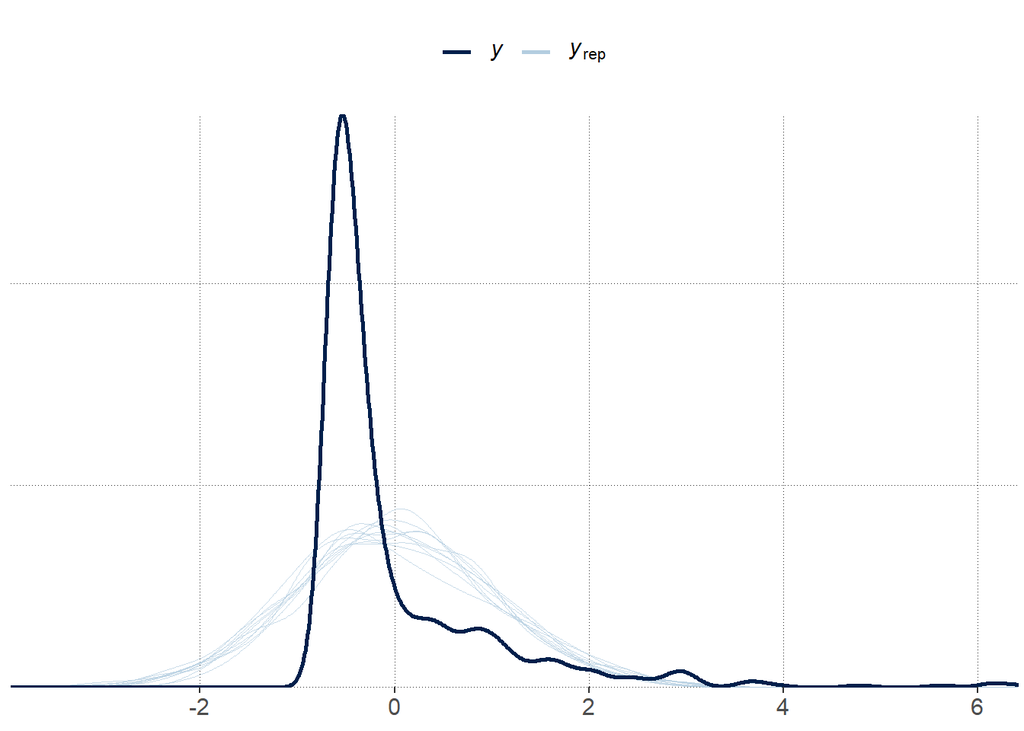

```r
#fit the model
pp_check(model_hypo1)
```

```r
# Extract the posteriors
posteriors1_trial_type <- model_hypo1 %>%
  spread_draws(b_Intercept,
               b_trial_typeTypical) %>%
  # calculate posteriors for each individual level
  mutate(Atypical = b_Intercept,
         Typical = b_Intercept + b_trial_typeTypical) %>%
  select(Atypical, Typical) %>%
  gather(key = "parameter", value = "posterior") %>%
  group_by(parameter) %>%
  summarise(mean_posterior = mean(posterior),
            `95lowerCrI` = HDInterval::hdi(posterior, credMass = 0.90)[1],
            `95higherCrI` = HDInterval::hdi(posterior, credMass = 0.90)[2])

posteriors1_trial_type
```

```
## # A tibble: 2 x 4
##   parameter mean_posterior `95lowerCrI` `95higherCrI`
##   <chr>              <dbl>        <dbl>         <dbl>
## 1 Atypical          0.306         0.122         0.504
## 2 Typical          -0.0458       -0.205         0.141
```

```r
# Extract the posteriors
posteriors1 <- model_hypo1 %>%
  spread_draws(b_trial_typeTypical) %>%
  select(b_trial_typeTypical) %>%
  gather(key = "parameter", value = "posterior")


posteriors1
```

```
## # A tibble: 4,000 x 2
##    parameter           posterior
##    <chr>                   <dbl>
##  1 b_trial_typeTypical    -0.317
##  2 b_trial_typeTypical    -0.385
##  3 b_trial_typeTypical    -0.448
##  4 b_trial_typeTypical    -0.462
##  5 b_trial_typeTypical    -0.255
##  6 b_trial_typeTypical    -0.256
##  7 b_trial_typeTypical    -0.357
##  8 b_trial_typeTypical    -0.382
##  9 b_trial_typeTypical    -0.194
## 10 b_trial_typeTypical    -0.332
## # ... with 3,990 more rows
```

```r
posterior1_agg <- posteriors1 %>%
  mutate(mean_posterior = mean(posterior))

posterior1_agg
```

```
## # A tibble: 4,000 x 3
##    parameter           posterior mean_posterior
##    <chr>                   <dbl>          <dbl>
##  1 b_trial_typeTypical    -0.317         -0.352
##  2 b_trial_typeTypical    -0.385         -0.352
##  3 b_trial_typeTypical    -0.448         -0.352
##  4 b_trial_typeTypical    -0.462         -0.352
##  5 b_trial_typeTypical    -0.255         -0.352
##  6 b_trial_typeTypical    -0.256         -0.352
##  7 b_trial_typeTypical    -0.357         -0.352
##  8 b_trial_typeTypical    -0.382         -0.352
##  9 b_trial_typeTypical    -0.194         -0.352
## 10 b_trial_typeTypical    -0.332         -0.352
## # ... with 3,990 more rows
```

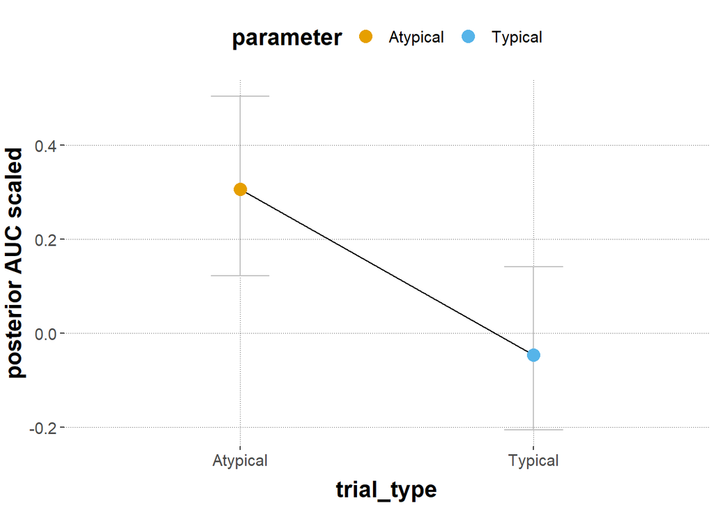

```r
# plot
ggplot(data = posteriors1_trial_type,
       aes(x = parameter, y = mean_posterior,
           color = parameter, fill = parameter)) +
  geom_errorbar(aes(ymin = `95lowerCrI`, ymax = `95higherCrI`),
                width = 0.2, color = "grey") +
  geom_line(aes(group = 1), color = "black") +
  geom_point(size = 4) +
  labs(x = "trial_type",
       y = "posterior AUC scaled")
```

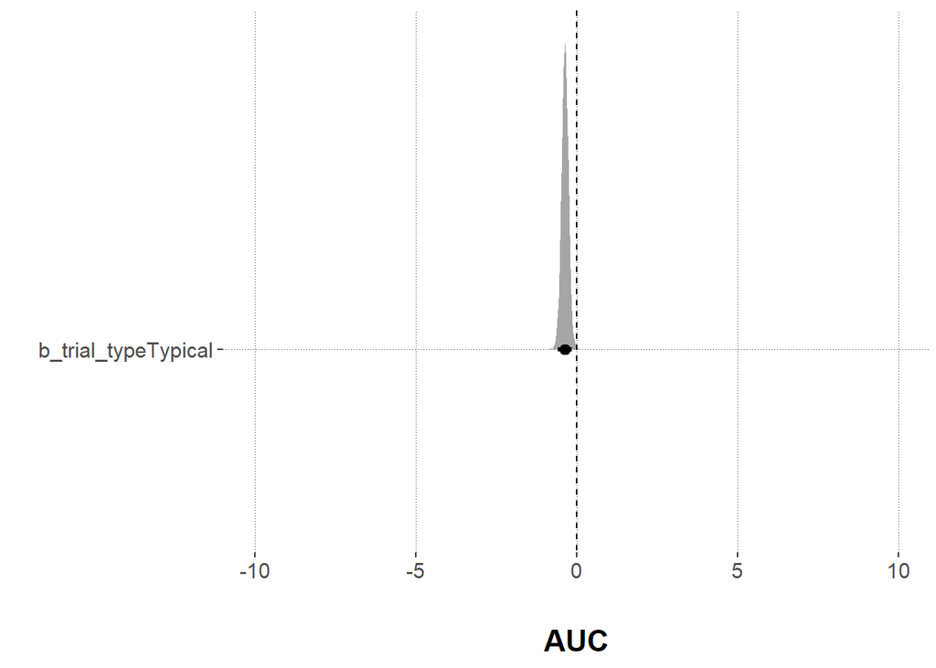

```r
# plot the regression coefficients
  ggplot(posteriors1, aes(x = posterior, y = parameter)) +
    # plot density
    geom_halfeyeh(.width = 0.95) +
    # add axes titles
    xlab("\nAUC") +
    ylab("") +
    # adjust the x-axis
    scale_x_continuous(limits = c(-10,10)) +
    # add line for the value zero
    geom_segment(x = 0, xend = 0, y = Inf, yend = -Inf,
                 lty = "dashed")
```

```r
#computing evidential ratio and posterior probability
hypothesis(model_hypo1, "trial_typeTypical > -0.34")
```

```
## Hypothesis Tests for class b:
##                 Hypothesis Estimate Est.Error CI.Lower CI.Upper Evid.Ratio
## 1 (trial_typeTypica... > 0    -0.01      0.11    -0.19     0.16       0.83
##   Post.Prob Star
## 1      0.45
## ---
## 'CI': 90%-CI for one-sided and 95%-CI for two-sided hypotheses.
## '*': For one-sided hypotheses, the posterior probability exceeds 95%;
## for two-sided hypotheses, the value tested against lies outside the 95%-CI.
## Posterior probabilities of point hypotheses assume equal prior probabilities.
```

Results: Mean posterior AUC values are higher for Atypical than Typical trial types, due to the negative slope going from the reference level (Atypical) to the Typical trial type. The credible interval of the coefficient trial_typeTypical does not include 0, wherefore there is evidence for the hypothesis to hold true. The credible interval values are however very close to 0. The evidence ratio for the hypothesis to hold true is 0.83 and the posterior probability is 45%. Because both of the values are small, we can assume that the evidence for the hypothesis to hold true is not noteworthy.

Hypothesis 2

```r
#Taking absolute AUC values, since negative AUC make no sense
animal$MAD_abs = abs(animal$MAD)
animal$MAD_abs_s = my_scale(animal$MAD_abs)

#informative prior
prior_hypo2 <- c(
  #priors for all fixed effects (trial_type)
  set_prior("student_t(3, 0,2)", class = "sigma"),
  #prior for the Intercept
  set_prior("student_t(3, -0.5,2)", class = "Intercept"),
  #prior for all SDs including the varying intercepts and slopes
  set_prior("student_t(3, 0, 2)", class = "sd")
)


#by-subject_id varying intercepts and varying
#slope, without slope/intercept correlation
#by-exemplar varying intercept
model_hypo2 = brm(
  MAD_abs_s ~ trial_type +
    (trial_type || subject_id)+
    (1|exemplar),
  control=list(adapt_delta=0.99, max_treedepth=15),
  data = animal,
  prior = prior_hypo2
  )

#looking at model
model_hypo2
```

```
##  Family: gaussian
##   Links: mu = identity; sigma = identity
## Formula: MAD_abs_s ~ trial_type + (trial_type || subject_id) + (1 | exemplar)
##    Data: animal (Number of observations: 598)
## Samples: 4 chains, each with iter = 2000; warmup = 1000; thin = 1;
##          total post-warmup samples = 4000
##
## Group-Level Effects:
## ~exemplar (Number of levels: 15)
##               Estimate Est.Error l-95% CI u-95% CI Rhat Bulk_ESS Tail_ESS
## sd(Intercept)     0.10      0.06     0.01     0.23 1.00     1207     1961
##
## ~subject_id (Number of levels: 53)
##                       Estimate Est.Error l-95% CI u-95% CI Rhat Bulk_ESS
## sd(Intercept)             0.51      0.08     0.37     0.67 1.00     1052
## sd(trial_typeTypical)     0.25      0.13     0.02     0.50 1.01      428
##                       Tail_ESS
## sd(Intercept)             2152
## sd(trial_typeTypical)      942
##
## Population-Level Effects:
##                   Estimate Est.Error l-95% CI u-95% CI Rhat Bulk_ESS Tail_ESS
## Intercept             0.35      0.11     0.14     0.57 1.00     2890     3341
## trial_typeTypical    -0.42      0.11    -0.65    -0.21 1.00     3714     3049
##
## Family Specific Parameters:
##       Estimate Est.Error l-95% CI u-95% CI Rhat Bulk_ESS Tail_ESS
## sigma     0.86      0.03     0.80     0.91 1.00     1887     2611
##
## Samples were drawn using sampling(NUTS). For each parameter, Bulk_ESS
## and Tail_ESS are effective sample size measures, and Rhat is the potential
## scale reduction factor on split chains (at convergence, Rhat = 1).
```

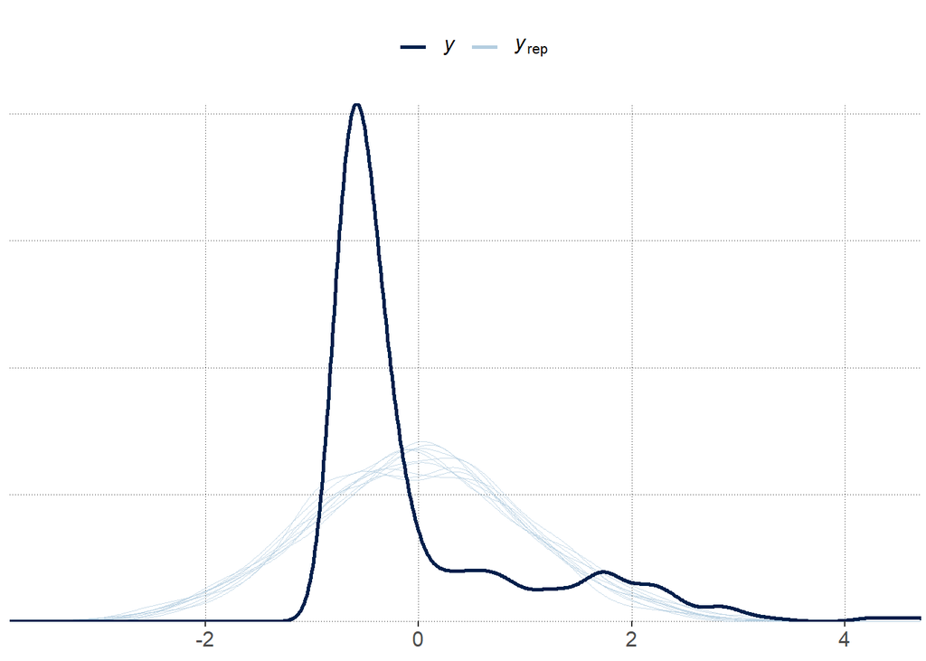

```r
#fitting model to actual data
pp_check(model_hypo2)
```

```r
# Extract the posteriors
posteriors2_trial_type <- model_hypo2 %>%
  spread_draws(b_Intercept,
               b_trial_typeTypical) %>%
  # calculate posteriors for each individual level
  mutate(Atypical = b_Intercept,
         Typical = b_Intercept + b_trial_typeTypical) %>%
  select(Atypical, Typical) %>%
  gather(key = "parameter", value = "posterior") %>%
  group_by(parameter) %>%
  summarise(mean_posterior = mean(posterior),
            `95lowerCrI` = HDInterval::hdi(posterior, credMass = 0.90)[1],
            `95higherCrI` = HDInterval::hdi(posterior, credMass = 0.90)[2])

posteriors2_trial_type
```

```
## # A tibble: 2 x 4
##   parameter mean_posterior `95lowerCrI` `95higherCrI`
##   <chr>              <dbl>        <dbl>         <dbl>
## 1 Atypical          0.348         0.165        0.523
## 2 Typical          -0.0736       -0.239        0.0776
```

```r
# Extract the posteriors
posteriors2 <- model_hypo2 %>%
  spread_draws(b_trial_typeTypical) %>%
  select(b_trial_typeTypical) %>%
  gather(key = "parameter", value = "posterior")


posteriors2
```

```
## # A tibble: 4,000 x 2
##    parameter           posterior
##    <chr>                   <dbl>
##  1 b_trial_typeTypical    -0.275
##  2 b_trial_typeTypical    -0.621
##  3 b_trial_typeTypical    -0.225
##  4 b_trial_typeTypical    -0.391
##  5 b_trial_typeTypical    -0.243
##  6 b_trial_typeTypical    -0.343
##  7 b_trial_typeTypical    -0.575
##  8 b_trial_typeTypical    -0.389
##  9 b_trial_typeTypical    -0.457
## 10 b_trial_typeTypical    -0.566
## # ... with 3,990 more rows
```

```r
posterior2_agg <- posteriors2 %>%
  mutate(mean_posterior = mean(posterior))

posterior2_agg
```

```
## # A tibble: 4,000 x 3
##    parameter           posterior mean_posterior
##    <chr>                   <dbl>          <dbl>
##  1 b_trial_typeTypical    -0.275         -0.421
##  2 b_trial_typeTypical    -0.621         -0.421
##  3 b_trial_typeTypical    -0.225         -0.421
##  4 b_trial_typeTypical    -0.391         -0.421
##  5 b_trial_typeTypical    -0.243         -0.421
##  6 b_trial_typeTypical    -0.343         -0.421
##  7 b_trial_typeTypical    -0.575         -0.421
##  8 b_trial_typeTypical    -0.389         -0.421
##  9 b_trial_typeTypical    -0.457         -0.421
## 10 b_trial_typeTypical    -0.566         -0.421
## # ... with 3,990 more rows
```

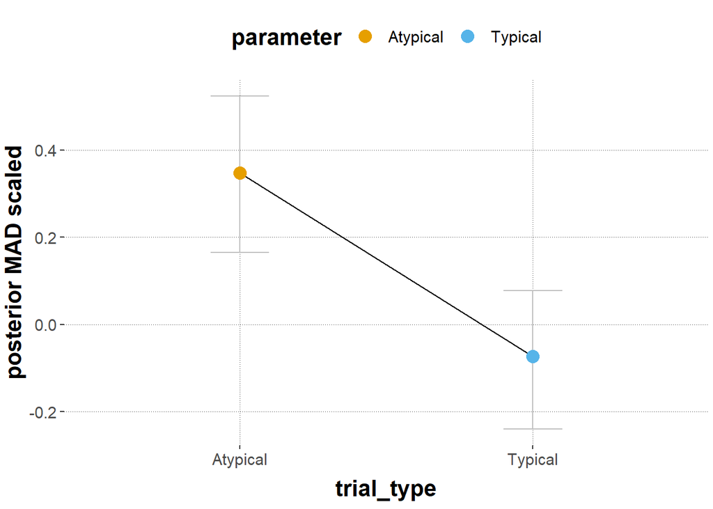

```r
# plot
ggplot(data = posteriors2_trial_type,
       aes(x = parameter, y = mean_posterior,
           color = parameter, fill = parameter)) +
  geom_errorbar(aes(ymin = `95lowerCrI`, ymax = `95higherCrI`),
                width = 0.2, color = "grey") +
  geom_line(aes(group = 1), color = "black") +
  geom_point(size = 4) +
  labs(x = "trial_type",
       y = "posterior MAD scaled")
```